# zadanie_irys

## O Danych

Zbiór danych zawiera informacje o trzech gatunkach irysów: Iris setosa, Iris versicolor, i Iris virginica.

Dane obejmują pomiary czterech cech: długość i szerokość działki kielicha oraz długość i szerokość płatka.

Każdy wiersz w zbiorze danych reprezentuje pojedynczy kwiat, a wartości pomiarów są podane w centymetrach.

Zbiór składa się z 150 próbek, po 50 dla każdego gatunku, i jest szeroko stosowany jako podstawowy zbiór danych do testowania algorytmów klasyfikacji oraz w nauce o danych i uczeniu maszynowym.

Kolumny:

- **długość kielicha (sepal length)** - Długość kielicha w cm
- **szerokość kielicha (sepal width)** - Szerokość kielicha w cm
- **długość płatka (petal length)** - Długość płatka w cm
- **szerokość płatka (petal width)** - Szerokość płatka w cm
- **klasa (class)** - Klasa irysa (setosa, versicolor, virginica)

|  | długość kielicha (sepal length) | szerokość kielicha (sepal width) | długość płatka (petal length) | szerokość płatka (petal width) | klasa (class) |
| --- | --- | --- | --- | --- | --- |
| 0 | 5.1 | 3.5 | 1.4 | 0.2 | Iris-setosa |
| 1 | 4.9 | 3.0 | 1.4 | 0.2 | Iris-setosa |
| 2 | 4.7 | 3.2 | 1.3 | 0.2 | Iris-setosa |
| 3 | 4.6 | 3.1 | 1.5 | 0.2 | Iris-setosa |
| 4 | 5.0 | 3.6 | 1.4 | 0.2 | Iris-setosa |
| ... | ... | ... | ... | ... | ... |
| 145 | 6.7 | 3.0 | 5.2 | 2.3 | Iris-virginica |
| 146 | 6.3 | 2.5 | 5.0 | 1.9 | Iris-virginica |
| 147 | 6.5 | 3.0 | 5.2 | 2.0 | Iris-virginica |
| 148 | 6.2 | 3.4 | 5.4 | 2.3 | Iris-virginica |
| 149 | 5.9 | 3.0 | 5.1 | 1.8 | Iris-virginica |

150 rows × 5 columns

# Ogólny przegląd danych

```
długość kielicha (sepal length)     150
szerokość kielicha (sepal width)    150
długość płatka (petal length)       150
szerokość płatka (petal width)      150
klasa (class)                       150
dtype: int64
```

```
<class 'pandas.core.frame.DataFrame'>
RangeIndex: 150 entries, 0 to 149
Data columns (total 5 columns):
 #   Column                            Non-Null Count  Dtype
---  ------                            --------------  -----
 0   długość kielicha (sepal length)   150 non-null    float64
 1   szerokość kielicha (sepal width)  150 non-null    float64
 2   długość płatka (petal length)     150 non-null    float64
 3   szerokość płatka (petal width)    150 non-null    float64
 4   klasa (class)                     150 non-null    object
dtypes: float64(4), object(1)
memory usage: 6.0+ KB
```

```
3
```

**Dane przedstawiają informacje z analizy 150 unikatowych irysów należących do 3 podgatunków**

|  | długość kielicha (sepal length) | szerokość kielicha (sepal width) | długość płatka (petal length) | szerokość płatka (petal width) |
| --- | --- | --- | --- | --- |
| count | 150.000000 | 150.000000 | 150.000000 | 150.000000 |
| mean | 5.843333 | 3.054000 | 3.758667 | 1.198667 |
| std | 0.828066 | 0.433594 | 1.764420 | 0.763161 |
| min | 4.300000 | 2.000000 | 1.000000 | 0.100000 |
| 25% | 5.100000 | 2.800000 | 1.600000 | 0.300000 |
| 50% | 5.800000 | 3.000000 | 4.350000 | 1.300000 |
| 75% | 6.400000 | 3.300000 | 5.100000 | 1.800000 |
| max | 7.900000 | 4.400000 | 6.900000 | 2.500000 |

# Analiza pojedynczych zmiennych

|  | klasa (class) | długość kielicha (sepal length) | szerokość kielicha (sepal width) | długość płatka (petal length) | szerokość płatka (petal width) |
| --- | --- | --- | --- | --- | --- |
| 0 | Iris-setosa | 5.006 | 3.418 | 1.464 | 0.244 |
| 1 | Iris-versicolor | 5.936 | 2.770 | 4.260 | 1.326 |
| 2 | Iris-virginica | 6.588 | 2.974 | 5.552 | 2.026 |

**W zależności od podgatunku widzimy duże zmaiany w średnich rozmiarach**

**Histogram wizualizuję zależność z widocznymi wzrostami dla średnich wartości.**

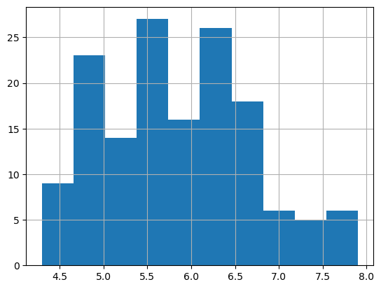

**Zależności dla klasy Iris-setosa**

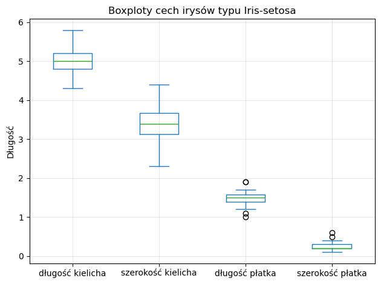

**Zależności dla klasy Iris-versicolor**

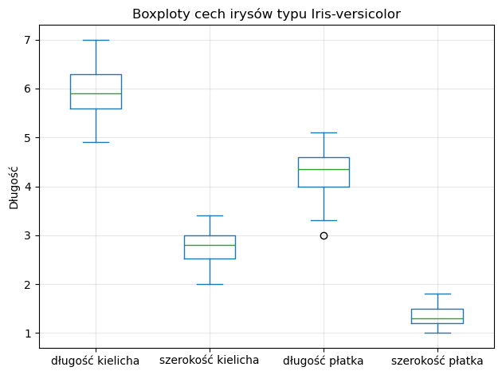

**Zależności dla klasy Iris-virginica**

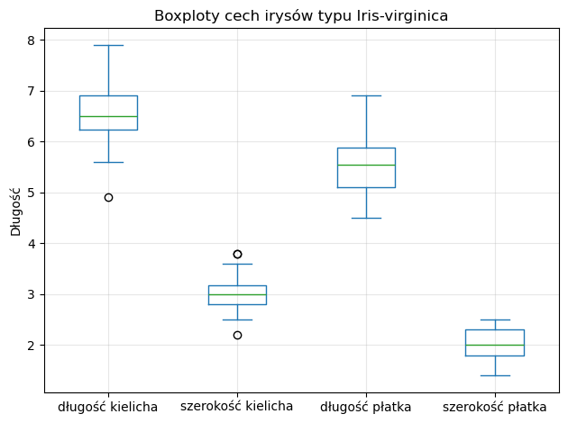

# Analiza korelacji

**Iris-setosa**

|  | długość kielicha | szerokość kielicha | długość płatka | szerokość płatka |
| --- | --- | --- | --- | --- |
| długość kielicha | 1.000000 | 0.746780 | 0.263874 | 0.279092 |
| szerokość kielicha | 0.746780 | 1.000000 | 0.176695 | 0.279973 |
| długość płatka | 0.263874 | 0.176695 | 1.000000 | 0.306308 |
| szerokość płatka | 0.279092 | 0.279973 | 0.306308 | 1.000000 |

**Iris-versicolor**

|  | długość kielicha | szerokość kielicha | długość płatka | szerokość płatka |
| --- | --- | --- | --- | --- |
| długość kielicha | 1.000000 | 0.525911 | 0.754049 | 0.546461 |
| szerokość kielicha | 0.525911 | 1.000000 | 0.560522 | 0.663999 |
| długość płatka | 0.754049 | 0.560522 | 1.000000 | 0.786668 |
| szerokość płatka | 0.546461 | 0.663999 | 0.786668 | 1.000000 |

**Iris-virginica**

|  | długość kielicha | szerokość kielicha | długość płatka | szerokość płatka |
| --- | --- | --- | --- | --- |
| długość kielicha | 1.000000 | 0.457228 | 0.864225 | 0.281108 |
| szerokość kielicha | 0.457228 | 1.000000 | 0.401045 | 0.537728 |
| długość płatka | 0.864225 | 0.401045 | 1.000000 | 0.322108 |
| szerokość płatka | 0.281108 | 0.537728 | 0.322108 | 1.000000 |

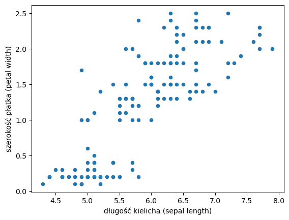

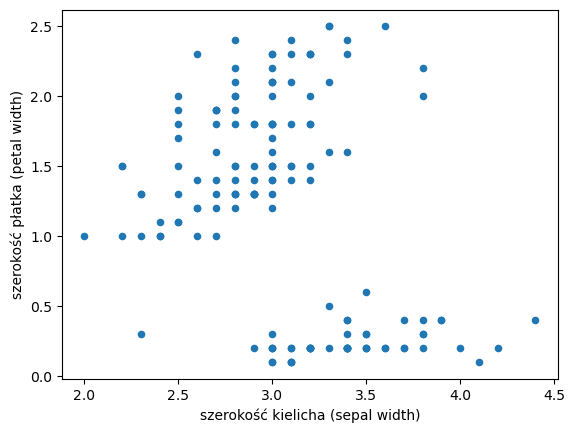

**Dla szerokości zależność jest prawie że odwrotna. Zmiany są bardzo nieproporcjonalne co prawdopodobnie wynika z różnic między klasami**  
**Istnije niewiele mutacji, chociaż występują osobniki z bardzo unikatowymi rozmiarami.**

# Wnioski:

- Rożnice w tej samej klasie są niewielkie
- Iris-setosa wyróżnia się małą długością płatka
- Brak pustych wpisów
- W zależności od gatunku istnieją różne korelacje między wielkością poszczególnych elementów